# DataChallenge

Di Wu

2023-03-29

## Background

The Etna Township Trustees appointed fifteen (15) community residents to the Community Advisory Committee to help guide the creation of the Township’s next comprehensive plan.

The Etna Township Comprehensive Plan Community Advisory Committee meets on the 2nd Wednesday of each month beginning at 6:00pm. The public is encouraged to attend. The meeting is held at the Etna Township building, 51 Liberty Street.

Together with Neighborhood Strategies (our planning consultant), the Community Advisory Committee has drafted the following public survey. Survey questions were designed to help the committee gather information about public sentiment on a variety of issues affecting the future of the Etna Township. Questions asked for basic demographic information, as well as opinions regarding current and future services, and development within the community. One of the most important considerations when formulating a comprehensive plan is public input.

## Data Exploration

```r
library(readxl)
library(dplyr)
library(tidyverse)
library(ggplot2)
library(GGally)
library(stringr)
library(Dict)
```

```r
MyData <- read_excel("C:/Users/62666/Desktop/Data.xlsx")
```

The data has following questions: Q1: What is your relationship to the Township?

Q2: In what section of the township do you live?

Q3: How many years have you lived in the Township?

Q4: What are the ages of those living in your house? Check all that apply.

Q5: Where do members of your household work? Check all that apply.

Q6: What are the top two reasons you live in the Township?

Q7: Do you rent or own your home?

Q8: Is farming your family’s primary source of income?

Q9: If you are a farmer, how many acres do you own?

Q10: How many acres do you own?

Q11: How likely are you to sell your property in the next 12 months

Q12: The Township needs more of which type(s) of housing units? Check all that apply.

Q13: Would You Consider Yourself:

Q14: Which type(s) of commercial development would you like to see in the Township? Check all that apply.

Q15: Which_type(s) of job-creating employment opportunities would you like to see in the Township? Check all that apply.

Q16: What are methods of encouraging businesses/industry you would support?

Q17: Would you like to see more public parkland in the Township?

Q18: How important is it to use land use planning and zoning in the following manner:

Q19: Do you feel the following services are needed or should be improved? Check all that apply.

Q20: Items for which you would support an additional tax. Check all that apply.

Q21: Which type of tax would you support for such services?

Q22: In your opinion, is it important to work with adjacent communities to coordinate growth?

Q23: Do you think a bike path system should be strategically created for recreation and possibly commuting purposes in the Township?

Q24: Please feel free to comment on issues affecting the Township that are not addressed in this survey.

```r
# Get the current column names
current_colnames <- colnames(MyData)

# Replace spaces with underscores
new_colnames <- gsub(" ", "_", current_colnames)

# Assign the new column names to the data frame
colnames(MyData) <- new_colnames
```

```r
MyData <- MyData[,-c(2:9)]
current_colnames <- colnames(MyData)
```

```r
questions_info <- list(
  list(question = 1, start_col = 6, end_col = 10, choices = c("I live in Etna Township", "Don't live here but own property in the Township", "Own a business in the Township", "I work in Etna Township but live elsewhere","Other (please specify)")),
  list(question = 2, start_col = 11, end_col = 11, choices = c("Response")),
  list(question = 3, start_col = 12, end_col = 17, choices = c("0 - 4 Years", "5 - 9 Years", "10 - 19 Years", "20 - 39 Years", "Over 40 Years", "I do not live in the Township")),
  list(question = 4, start_col = 18, end_col = 24, choices = c("0 - 5 Years Old", "6 - 12 Years Old", "13 - 18 Years Old", "19 - 25 Years Old", "26 - 44 Years Old", "45 - 65 Years Old", "66+ Years Old")),
  list(question = 5, start_col = 25, end_col = 37, choices = c("Etna Township", "Reynoldsburg", "Newark", "Granville", "Johnstown", "Pataskala", "Columbus", "New Albany", "Heath", "Elsewhere in Licking County", "Elsewhere in Franklin County", "Retired", "Unemployed")),
  list(question = 6, start_col = 38, end_col = 46, choices = c("Quiet for Retirement", "Access to Employment", "Friendliness", "Cleanliness", "School System", "Lack of Congestion", "Rural Atmosphere", "My Family has Lived Here for Generations", "Other (please specify)")),
  list(question = 7, start_col = 47, end_col = 47, choices = c("Response")),
  list(question = 8, start_col = 48, end_col = 48, choices = c("Response")),
  list(question = 9, start_col = 49, end_col = 49, choices = c("Response")),
  list(question = 10, start_col = 50, end_col = 50, choices = c("Response")),
  list(question = 11, start_col = 51, end_col = 51, choices = c("Open-Ended Response")),
  list(question = 12, start_col = 52, end_col = 58, choices = c("None of the above", "Farm House/Large Lot", "Single Family","Townhome/Condo", "Accessory Dwelling Units", "Senior/Assisted Living", "Gated Communities")),
  list(question = 13, start_col = 59, end_col = 59, choices = c("Response")),
  list(question = 14, start_col = 60, end_col = 67, choices = c("Large Shopping Mall (Easton/Polaris)", "Strip Shopping Areas", "Rural Home Occupations", "Neighborhood Commercial", "Agri-Business", "Manufacturing", "Logistics & Warehousing", "Other (please specify)")),
  list(question = 15, start_col = 68, end_col = 74, choices = c("None of the above", "Light Manufacturing", "Heavy Manufacturing", "Office/Service", "Recreation/Resort Activity", "Maintain Current Farming and Agricultural Base", "Other (please specify)")),
  list(question = 16, start_col = 75, end_col = 81, choices = c("None of the above", "Tax Reductions", "Relaxed Zoning", "Job Training", "Business Centers", "Industrial Park", "Other (please specify)")),
  list(question = 17, start_col = 82, end_col = 82, choices = c("Response")),
  list(question = 18, start_col = 83, end_col = 87, choices = c("Protection of Flood Plains", "Protection of Sensitive Wetlands", "Protection of Steep Areas Prone to Erosion", "Protection of Farmland", "Protection of Air Quality")),
  list(question = 19, start_col = 88, end_col = 95, choices = c("None of the above", "Broadband Internet", "Central Water", "Central Sewer", "Recycling", "Adopt-A-Highway", "Natural Gas", "Other (please specify)")),
  list(question = 20, start_col = 96, end_col = 105, choices = c("None of the above", "Recycling", "Fire Station Facility", "Improve Emergency Services", "Improve Schools", "Provide Social Services For All Ages", "Improve Police Protection", "Central Water and Sewer Facilities", "Improve/Provide Parks and Recreation Facilities", "Other (please specify)")),
  list(question = 21, start_col = 106, end_col = 107, choices = c("Response", "Other (please specify)")),
  list(question = 22, start_col = 108, end_col = 108, choices = c("Response")),
  list(question = 23, start_col = 109, end_col = 110, choices = c("Response", "Maybe (please specify)")),
  list(question = 24, start_col = 111, end_col = 111, choices = c("Open-Ended Response"))

)
```

```r
# Extract the first row
choices_row <- unlist(MyData[1, ], use.names = FALSE)
survey_data <- MyData[-1, ]
# Create an empty data frame with the same number of rows as the original data
encoded_data <- data.frame(matrix(ncol = 0, nrow = nrow(survey_data)))

# Add new columns to the data frame
for (question_info in questions_info) {
  question <- question_info$question
  choices <- question_info$choices

  for (choice in choices) {
    new_column_name <- paste0("Q", question, "_", choice)
    encoded_data[[new_column_name]] <- NA
  }
}
encoded_data <- cbind(Respondent_ID=survey_data[,1], encoded_data)
```

```r
MyData1 <- MyData
exclude_columns <- c(6, 7, 43, 44, 45, 46, 47, 55, 63, 70, 77, 78, 79, 80, 81, 82, 83, 91, 101, 102, 103, 104, 105, 106, 107)

for (row_index in 2:nrow(MyData1)) {

  for (col_index in 1:ncol(MyData1)) {
    if (!is.na(MyData1[row_index, col_index]) && !is.na(MyData1[1, col_index])) {
      if (MyData1[row_index, col_index] == MyData1[1, col_index]) {
        MyData1[row_index, col_index] <- "1"
      }
    }
    if (!(col_index %in% exclude_columns)) {
      if (is.na(MyData1[row_index, col_index])) {
        MyData1[row_index, col_index] <- "0"
      }
    }
  }
}
```

```r
MyData1 <- MyData1[-1,]
colnames(MyData1) <- colnames(encoded_data)
```

### Q1: Relationship to the Township

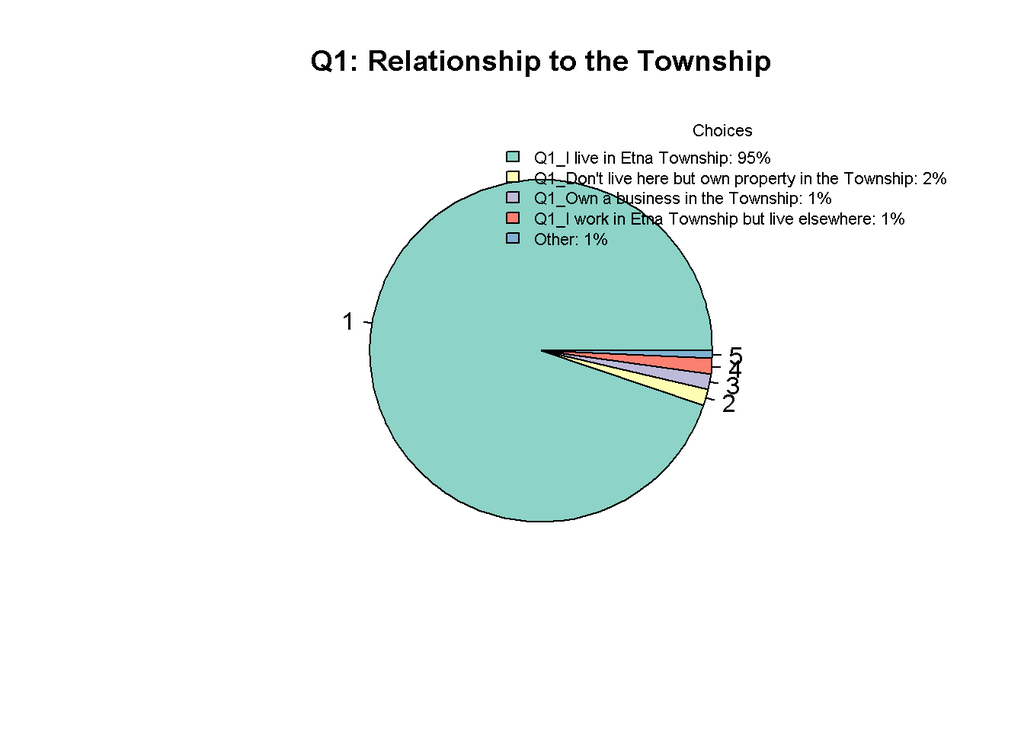

```r
library(RColorBrewer)
colors <- brewer.pal(n = 6, name = "Set3")
# Assuming your data frame is named 'data'
q1_columns <- MyData1[, 2:5]  # Adjust the column indices according to your data frame
q1_other_counts <- sum(MyData1[, 6] != "", na.rm = TRUE)
q1_counts <- colSums(q1_columns == "1", na.rm = TRUE)
q1_summary <- data.frame(choice = c(colnames(q1_columns), "Other"), count = c(q1_counts, q1_other_counts))
q1_summary$percentage <- q1_summary$count / sum(q1_summary$count) * 100
pie(q1_summary$count, labels = NULL, col = colors, main = "Q1: Relationship to the Township")
pie_percent <- round(q1_summary$percentage)
pie_labels <- paste0(q1_summary$choice, ": ", pie_percent, "%")
legend("topright", legend = pie_labels, fill = colors, bty = "n", title = "Choices", text.font = 1, cex = 0.7, inset = c(0.009, -0.009))
```

### Q3: Years Lived in the Township

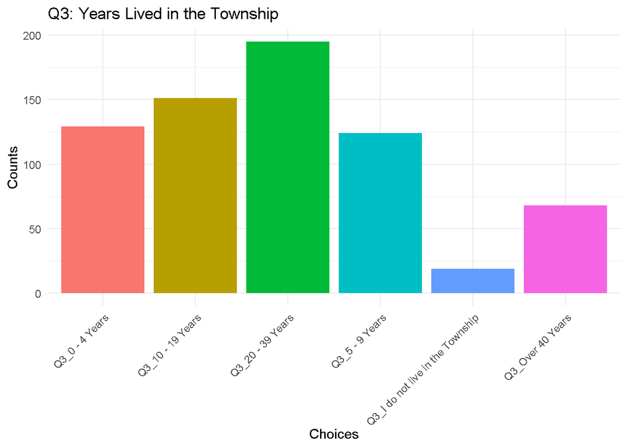

```r
q3_columns <- MyData1[, 8:13]  # Adjust the column indices according to your data frame
q3_counts <- colSums(q3_columns == 1, na.rm = TRUE)
q3_summary <- data.frame(choice = colnames(q3_columns), count = q3_counts)
ggplot(q3_summary, aes(x = choice, y = count, fill = choice)) +
  geom_bar(stat = "identity", show.legend = FALSE) +
  theme_minimal() +
  labs(title = "Q3: Years Lived in the Township", x = "Choices", y = "Counts") +
  theme(axis.text.x = element_text(angle = 45, hjust = 1))
```

### Q4: What are the ages of those living in your house?

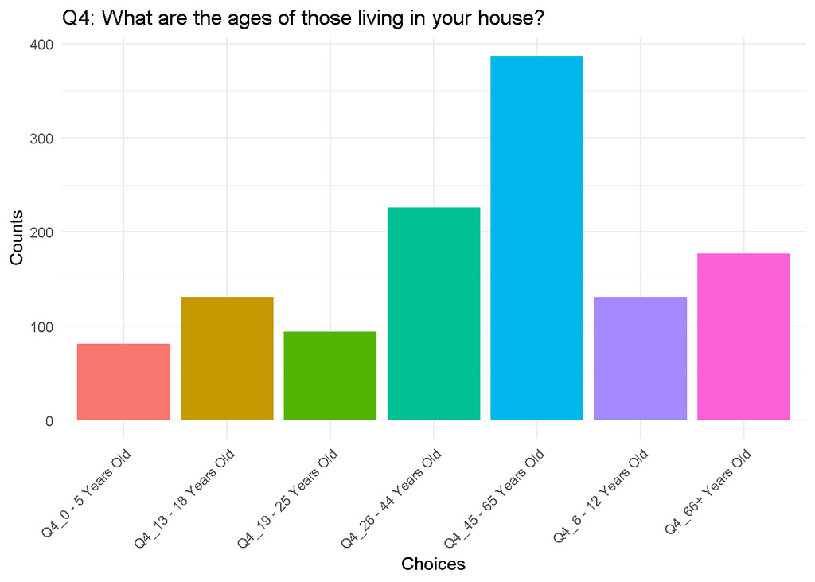

```r
q4_columns <- MyData1[, 14:20]  # Adjust the column indices according to your data frame
q4_counts <- colSums(q4_columns == 1, na.rm = TRUE)
q4_summary <- data.frame(choice = colnames(q4_columns), count = q4_counts)
ggplot(q4_summary, aes(x = choice, y = count, fill = choice)) +
  geom_bar(stat = "identity", show.legend = FALSE) +
  theme_minimal() +
  labs(title = "Q4: What are the ages of those living in your house?", x = "Choices", y = "Counts") +
  theme(axis.text.x = element_text(angle = 45, hjust = 1))
```

### Q6: Top Two Reasons for Living in the Township

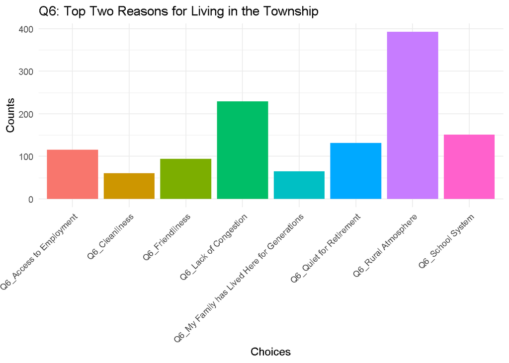

```r
q6_columns <- MyData1[, 34:41]
q6_counts <- colSums(q6_columns == 1, na.rm = TRUE)
q6_summary <- data.frame(choice = colnames(q6_columns), count = q6_counts)

ggplot(q6_summary, aes(x = choice, y = count, fill = choice)) +
  geom_bar(stat = "identity", show.legend = FALSE) +
  theme_minimal() +
  labs(title = "Q6: Top Two Reasons for Living in the Township", x = "Choices", y = "Counts") +
  theme(axis.text.x = element_text(angle = 45, hjust = 1))
```

## Statistical model for combinational qustions

### Q1: Linear Mixed Effect Model: How does the number of years living in the Township (Q3) affect the likelihood of selling property (Q11), accounting for random effects due to the section of the township (Q2)?

```r
library(lme4)
Q11 <- colnames(MyData1)[47]
Q2 <- colnames(MyData1)[7]
Q3_1 <- colnames(MyData1)[8]
Q3_2 <- colnames(MyData1)[9]
Q3_3 <- colnames(MyData1)[10]
Q3_4 <- colnames(MyData1)[11]
Q3_5 <- colnames(MyData1)[12]
Q3_6 <- colnames(MyData1)[13]
MyData1$"Q11_Open-Ended Response" <- as.numeric(MyData1$"Q11_Open-Ended Response")
model1 <- lmer(`Q11_Open-Ended Response` ~ `Q3_0 - 4 Years` + `Q3_5 - 9 Years` + `Q3_10 - 19 Years` + `Q3_20 - 39 Years` + `Q3_Over 40 Years` + `Q3_I do not live in the Township` + (1 | `Q2_Response`), data = MyData1)
summary(model1)
```

```
## Linear mixed model fit by REML ['lmerMod']
## Formula: `Q11_Open-Ended Response` ~ `Q3_0 - 4 Years` + `Q3_5 - 9 Years` +
##     `Q3_10 - 19 Years` + `Q3_20 - 39 Years` + `Q3_Over 40 Years` +
##     `Q3_I do not live in the Township` + (1 | Q2_Response)
##    Data: MyData1
##
## REML criterion at convergence: 6209.7
##
## Scaled residuals:
##     Min      1Q  Median      3Q     Max
## -3.1087 -0.5772  0.4527  0.7073  1.1925
##
## Random effects:
##  Groups      Name        Variance Std.Dev.
##  Q2_Response (Intercept)   4.42    2.102
##  Residual                764.95   27.658
## Number of obs: 659, groups:  Q2_Response, 6
##
## Fixed effects:
##                                     Estimate Std. Error t value
## (Intercept)                           93.071     14.405   6.461
## `Q3_0 - 4 Years`1                     -5.339     14.500  -0.368
## `Q3_5 - 9 Years`1                     -9.739     14.384  -0.677
## `Q3_10 - 19 Years`1                  -16.003     14.582  -1.097
## `Q3_20 - 39 Years`1                  -14.455     14.457  -1.000
## `Q3_Over 40 Years`1                  -12.388     14.800  -0.837
## `Q3_I do not live in the Township`1  -24.300     14.384  -1.689
##
## Correlation of Fixed Effects:
##             (Intr) `Q3-4Y `Q3-9Y `Q3-1Y `Q3-3Y `Q3_4Y
## `Q3_0-4Yr`1 -0.983
## `Q3_5-9Yr`1 -0.982  0.969
## `Q3_10-19Y` -0.985  0.973  0.972
## `Q3_20-39Y` -0.988  0.976  0.975  0.978
## `Q3_O40Yr`1 -0.969  0.957  0.956  0.959  0.962
## `Q3_IdnlitT -0.879  0.866  0.863  0.868  0.869  0.854
```

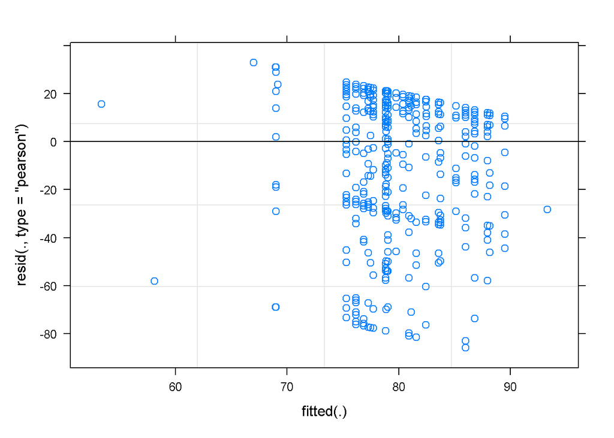

```r
plot(model1)
```

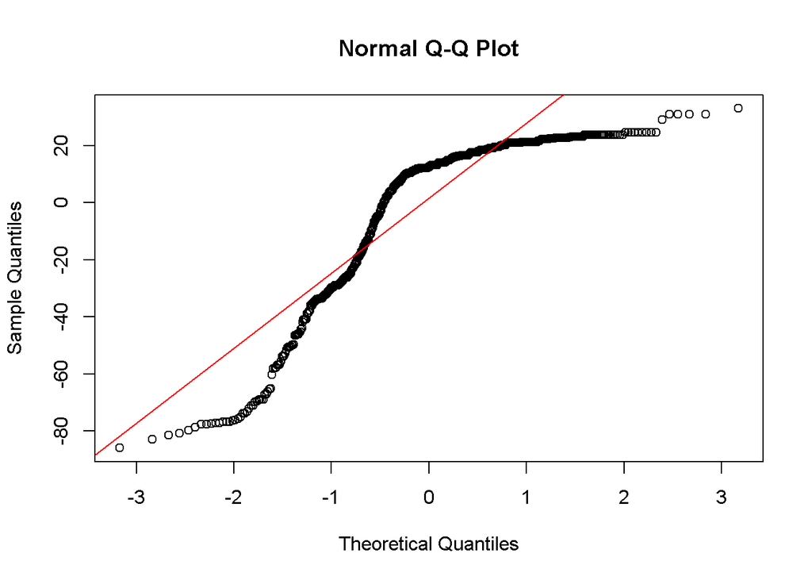

```r
qqnorm(resid(model1))
qqline(resid(model1), col = "red")
```

The qqplot of model1 for the linear mixed model1 shows the data are spread out than supposed at the quntiles.As a result, the number of years living in the Township (Q3) does less likely affect the likelihood of selling property (Q11), accounting for random effects due to the section of the township (Q2).